# Netflix Data Analysis

Netflix Data Analysis - Trends, Insights & Visualizations

Project Overview

This project focuses on analyzing Netflix’s title dataset to uncover patterns in content types, genres, durations, country contributions, and trends over the years. The goal is to turn raw data into actionable insights through data cleaning, visualization, and exploration.

```python
import pandas as pd
import numpy as np
import matplotlib.pyplot as plt
import seaborn as sns
%matplotlib inline
sns.set(style="whitegrid")
```

Dataset Overview

Source - Netflix Movies and TV Shows dataset

Columns - Title, Director, Cast, Country, Release Year, Rating, Duration, Genres, etc.

Missing Values - Some columns (like Director, Cast, Country) contain missing values.

```python
df = pd.read_csv('D:/SIBM/python course CWH/Mini project python/netflix_titles.csv')
df.head()
```

|  | show_id | type | title | director | cast | country | date_added | release_year | rating | duration | listed_in | description |
| --- | --- | --- | --- | --- | --- | --- | --- | --- | --- | --- | --- | --- |
| 0 | s1 | Movie | Dick Johnson Is Dead | Kirsten Johnson | NaN | United States | September 25, 2021 | 2020 | PG-13 | 90 min | Documentaries | As her father nears the end of his life, filmm... |
| 1 | s2 | TV Show | Blood & Water | NaN | Ama Qamata, Khosi Ngema, Gail Mabalane, Thaban... | South Africa | September 24, 2021 | 2021 | TV-MA | 2 Seasons | International TV Shows, TV Dramas, TV Mysteries | After crossing paths at a party, a Cape Town t... |
| 2 | s3 | TV Show | Ganglands | Julien Leclercq | Sami Bouajila, Tracy Gotoas, Samuel Jouy, Nabi... | NaN | September 24, 2021 | 2021 | TV-MA | 1 Season | Crime TV Shows, International TV Shows, TV Act... | To protect his family from a powerful drug lor... |
| 3 | s4 | TV Show | Jailbirds New Orleans | NaN | NaN | NaN | September 24, 2021 | 2021 | TV-MA | 1 Season | Docuseries, Reality TV | Feuds, flirtations and toilet talk go down amo... |
| 4 | s5 | TV Show | Kota Factory | NaN | Mayur More, Jitendra Kumar, Ranjan Raj, Alam K... | India | September 24, 2021 | 2021 | TV-MA | 2 Seasons | International TV Shows, Romantic TV Shows, TV ... | In a city of coaching centers known to train I... |

```python
df.shape
```

```
(8807, 12)
```

```python
df.info()
```

```
<class 'pandas.core.frame.DataFrame'>
RangeIndex: 8807 entries, 0 to 8806
Data columns (total 12 columns):
 #   Column        Non-Null Count  Dtype
---  ------        --------------  -----
 0   show_id       8807 non-null   object
 1   type          8807 non-null   object
 2   title         8807 non-null   object
 3   director      6173 non-null   object
 4   cast          7982 non-null   object
 5   country       7976 non-null   object
 6   date_added    8797 non-null   object
 7   release_year  8807 non-null   int64
 8   rating        8803 non-null   object
 9   duration      8804 non-null   object
 10  listed_in     8807 non-null   object
 11  description   8807 non-null   object
dtypes: int64(1), object(11)
memory usage: 825.8+ KB
```

```python
df.describe()
```

|  | release_year |
| --- | --- |
| count | 8807.000000 |
| mean | 2014.180198 |
| std | 8.819312 |
| min | 1925.000000 |
| 25% | 2013.000000 |
| 50% | 2017.000000 |
| 75% | 2019.000000 |
| max | 2021.000000 |

Data Cleaning

1. Removed or handled missing values in key columns
2. Split multi-value fields like country, cast, and listed_in
3. Converted date_added to datetime and extracted year_added and month_added

```python
df.isnull().sum()
```

```
show_id            0
type               0
title              0
director        2634
cast             825
country          831
date_added        10
release_year       0
rating             4
duration           3
listed_in          0
description        0
dtype: int64
```

```python
df.dropna(subset=['rating','duration','date_added'], inplace = True)
```

```python
df.isnull().sum()
```

```
show_id            0
type               0
title              0
director        2621
cast             825
country          829
date_added         0
release_year       0
rating             0
duration           0
listed_in          0
description        0
dtype: int64
```

Exploratory Data Analysis (EDA)

Content Type Distribution -

Compared Movies vs TV Shows

Found that Movies account for ~70% of all Netflix content

```python
df['type'].value_counts()
```

```
Movie      6126
TV Show    2664
Name: type, dtype: int64
```

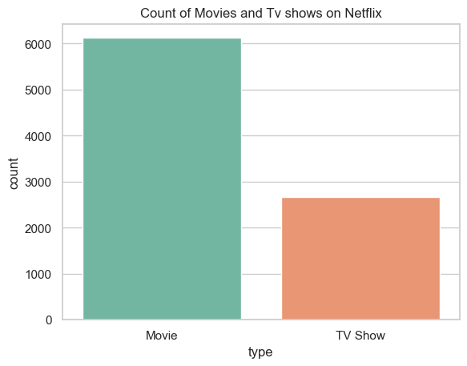

```python
sns.countplot(data=df, x='type', palette='Set2')
plt.title ("Count of Movies and Tv shows on Netflix")
plt.show()
```

Yearly Addition of Content -

Significant surge from 2017 to 2019

2019 had the highest content addition

Notable drop after 2020 (possibly due to COVID-19 impact)

```python
df['date_added'] = pd.to_datetime(df['date_added'])
```

```python
df['year_added'] = df['date_added'].dt.year
```

```python
df['year_added'].value_counts().sort_index()
```

```
2008.0       2
2009.0       2
2010.0       1
2011.0      13
2012.0       3
2013.0      11
2014.0      24
2015.0      82
2016.0     429
2017.0    1188
2018.0    1649
2019.0    2016
2020.0    1879
2021.0    1498
Name: year_added, dtype: int64
```

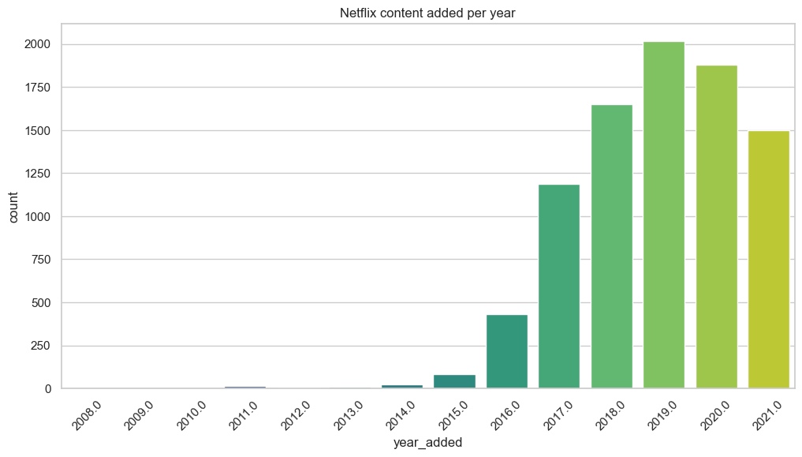

```python
plt.figure(figsize=(12,6))
sns.countplot(data = df, x='year_added', order = sorted(df['year_added'].dropna().unique()), palette='viridis')
plt.title("Netflix content added per year")
plt.xticks(rotation = 45)
plt.show()
```

```python
year_type = df.groupby(['year_added','type']).size().reset_index(name='count')
```

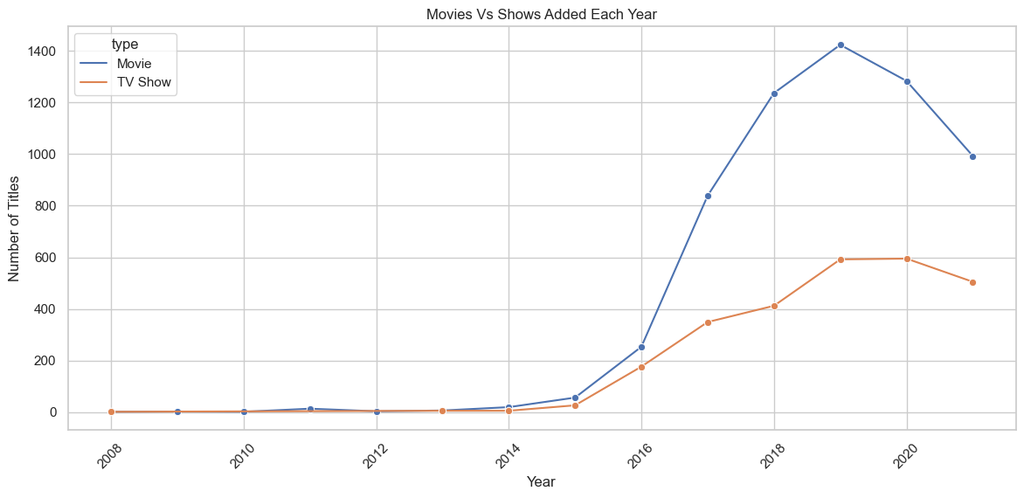

```python
plt.figure(figsize = (14,6))
sns.lineplot(data = year_type, x='year_added', y='count', hue ='type', marker='o')
plt.title("Movies Vs Shows Added Each Year")
plt.ylabel("Number of Titles")
plt.xlabel("Year")
plt.xticks(rotation = 45)
plt.grid(True)
plt.show()
```

Country-wise Content Production

United States, India, and UK are top contributors

Used Counter to analyze all countries from multi-country fields

```python
df['country'].value_counts(dropna=False).head(10)
```

[output not shown]

```python
df['country'] = df['country'].fillna('Unknown')
```

```python
from collections import Counter

country_list = df['country'].dropna().apply(lambda x: x.split(', '))
all_countries = [country for sublist in country_list for country in sublist]
country_count = Counter(all_countries)

country_df = pd.DataFrame(country_count.items(), columns = ['country','count'])
country_df = country_df.sort_values(by = 'count', ascending = False).head(10)
```

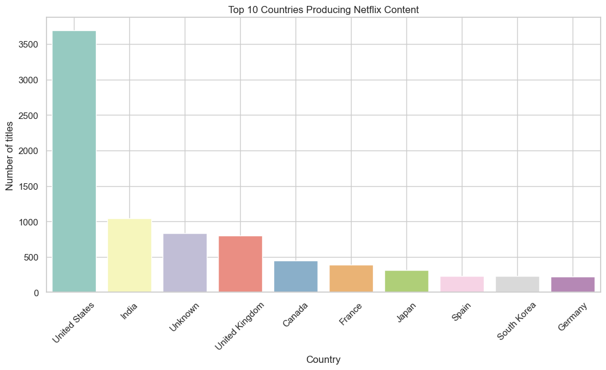

```python
plt.figure(figsize = (12,6))
sns.barplot(data = country_df, x='country', y='count', palette = 'Set3')
plt.title("Top 10 Countries Producing Netflix Content")
plt.xticks(rotation=45)
plt.ylabel("Number of titles")
plt.xlabel("Country")
plt.grid(True)
plt.show()
```

Genre Analysis -

Top genres: International Movies, Dramas, Comedies

```python
from collections import Counter

#spliting each row into a list of genres
genre_list = df['listed_in'].dropna().apply(lambda x: [genre.strip() for genre in x.split (',')])

#flatten the list
all_genres = [genre for sublist in genre_list for genre in sublist]

#count how often genre appears
genre_count = Counter(all_genres)

#converting to dataframe
genre_df = pd.DataFrame(genre_count.items(), columns =['genre','count'])

genre_df = genre_df.sort_values(by='count',ascending = False,).head(10).reset_index(drop=True)

print(genre_df)
```

```
                      genre  count
0      International Movies   2752
1                    Dramas   2427
2                  Comedies   1674
3    International TV Shows   1351
4             Documentaries    869
5        Action & Adventure    859
6                 TV Dramas    763
7        Independent Movies    756
8  Children & Family Movies    641
9           Romantic Movies    616
```

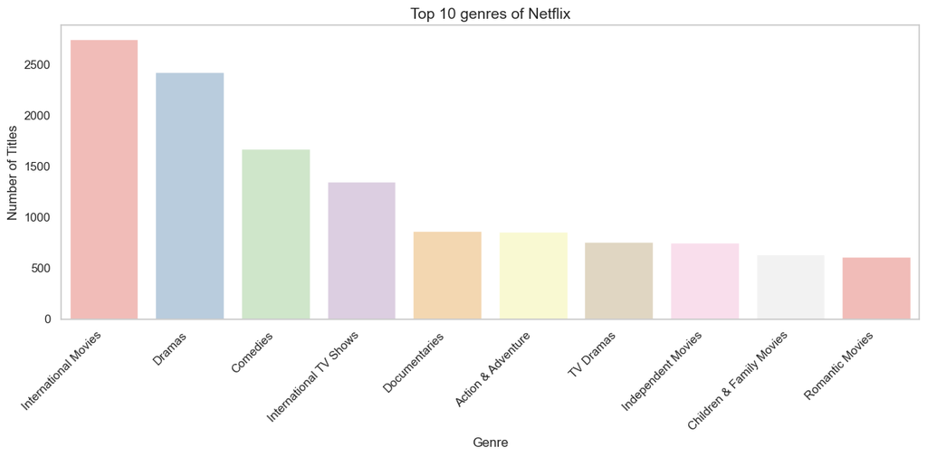

```python
plt.figure(figsize=(12,6))
sns.barplot(data = genre_df , x='genre' , y='count', palette = 'Pastel1')

plt.title("Top 10 genres of Netflix", fontsize = 14)
plt.xticks(rotation = 45, ha ='right')
plt.xlabel("Genre")
plt.ylabel("Number of Titles")
plt.grid(axis='y')
plt.tight_layout()
plt.show()
```

```python
movies = df [ df['type'] == 'Movie'].copy()
tv_shows = df [ df['type'] == 'TV Show' ].copy()

#For movies - extract the number of minutes
movies['duration_int'] = movies['duration'].str.extract('(\d+)').astype(float)

#for tv shows - extract number of seasons
tv_shows['duration_int'] = tv_shows['duration'].str.extract('(\d+)').astype(float)
```

```python
print( movies.shape[0])
print(tv_shows.shape[0])
movies.head()
tv_shows.head()
```

[output not shown]

|  | show_id | type | title | director | cast | country | date_added | release_year | rating | duration | listed_in | description | year_added | duration_int |
| --- | --- | --- | --- | --- | --- | --- | --- | --- | --- | --- | --- | --- | --- | --- |
| 1 | s2 | TV Show | Blood & Water | NaN | Ama Qamata, Khosi Ngema, Gail Mabalane, Thaban... | South Africa | 2021-09-24 | 2021 | TV-MA | 2 Seasons | International TV Shows, TV Dramas, TV Mysteries | After crossing paths at a party, a Cape Town t... | 2021.0 | 2.0 |
| 2 | s3 | TV Show | Ganglands | Julien Leclercq | Sami Bouajila, Tracy Gotoas, Samuel Jouy, Nabi... | Unknown | 2021-09-24 | 2021 | TV-MA | 1 Season | Crime TV Shows, International TV Shows, TV Act... | To protect his family from a powerful drug lor... | 2021.0 | 1.0 |
| 3 | s4 | TV Show | Jailbirds New Orleans | NaN | NaN | Unknown | 2021-09-24 | 2021 | TV-MA | 1 Season | Docuseries, Reality TV | Feuds, flirtations and toilet talk go down amo... | 2021.0 | 1.0 |
| 4 | s5 | TV Show | Kota Factory | NaN | Mayur More, Jitendra Kumar, Ranjan Raj, Alam K... | India | 2021-09-24 | 2021 | TV-MA | 2 Seasons | International TV Shows, Romantic TV Shows, TV ... | In a city of coaching centers known to train I... | 2021.0 | 2.0 |
| 5 | s6 | TV Show | Midnight Mass | Mike Flanagan | Kate Siegel, Zach Gilford, Hamish Linklater, H... | Unknown | 2021-09-24 | 2021 | TV-MA | 1 Season | TV Dramas, TV Horror, TV Mysteries | The arrival of a charismatic young priest brin... | 2021.0 | 1.0 |

Duration Insights -

Extracted numeric values from the duration field

Liechtenstein had the longest average movie duration

```python
#movie data
movie_countries = movies[['country','duration_int']].dropna()

#split multiple countries
movie_countries = movie_countries.assign(country=movie_countries['country'].str.split(', '))

#explode so that each row has one county
movie_countries = movie_countries.explode('country')
```

```python
#Group and average duration per country
avg_duration_by_country = movie_countries.groupby('country')['duration_int'].mean().sort_values(ascending = False).head(10)

#covert dataframe from plotting
avg_duration_df = avg_duration_by_country.reset_index()
```

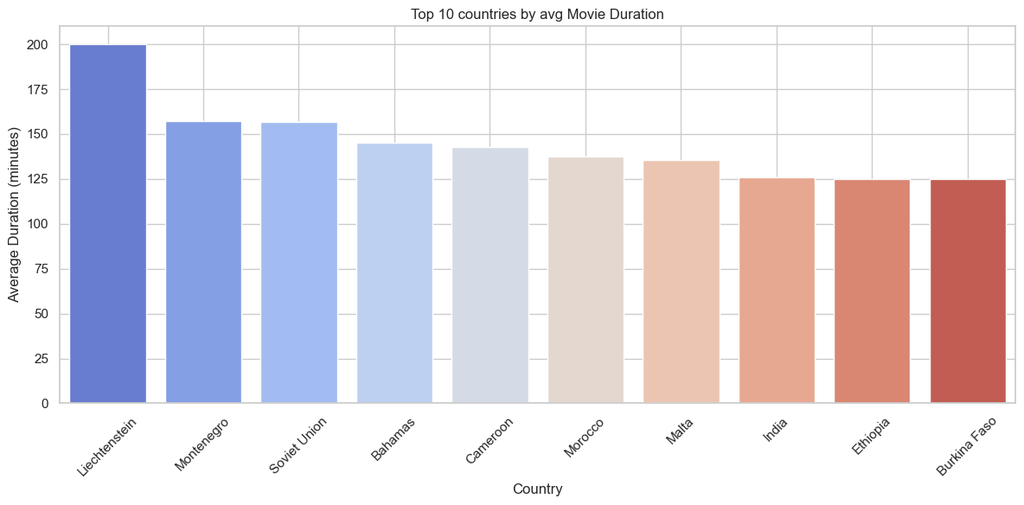

```python
plt.figure(figsize=(12,6))
sns.barplot(data = avg_duration_df, x='country', y='duration_int', palette = 'coolwarm')

plt.title("Top 10 countries by avg Movie Duration")
plt.xlabel("Country")
plt.ylabel("Average Duration (minutes)")
plt.xticks(rotation = 45)
plt.grid(True)
plt.tight_layout()
plt.show()
```

Rating Analysis -

Most content is rated TV-MA and TV-14

```python
df['rating'].value_counts(dropna=False)
```

[output not shown]

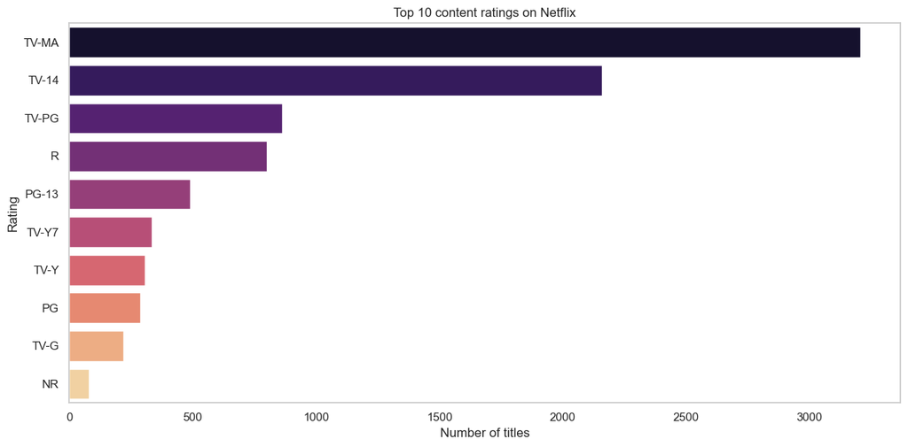

```python
plt.figure(figsize=(12,6))
sns.countplot(data = df, y='rating', order=df['rating'].value_counts().index[:10],palette='magma')
plt.title("Top 10 content ratings on Netflix")
plt.xlabel("Number of titles")
plt.ylabel("Rating")
plt.grid(axis ='x')
plt.tight_layout()
plt.show()
```

[figure not shown]

```python
plt.figure(figsize=(12,6))
sns.countplot(data=df, x='rating', hue='type', order=df['rating'].value_counts().index, palette = 'Set2')
plt.title("Rating Distribution by Content Type")
plt.xlabel("Rating")
plt.ylabel("Number of Titles")
plt.xticks(rotation=45)
plt.grid(axis='y')
plt.tight_layout()
plt.show()
```

```python
top_directors = df['director'].dropna().value_counts().head(10)
print(top_directors)
```

```
Rajiv Chilaka             19
Raúl Campos, Jan Suter    18
Marcus Raboy              16
Suhas Kadav               16
Jay Karas                 14
Cathy Garcia-Molina       13
Martin Scorsese           12
Youssef Chahine           12
Jay Chapman               12
Steven Spielberg          11
Name: director, dtype: int64
```

```
<function matplotlib.pyplot.show(close=None, block=None)>
```

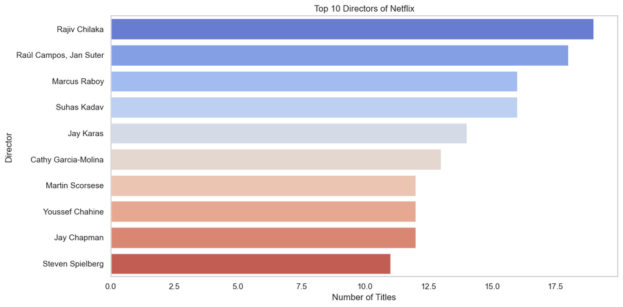

```python
plt.figure(figsize=(12,6))
sns.barplot(x=top_directors.values, y=top_directors.index, palette ='coolwarm')
plt.title("Top 10 Directors of Netflix")
plt.xlabel('Number of Titles')
plt.ylabel('Director')
plt.grid(axis='x')
plt.tight_layout()
plt.show
```

```python
from collections import Counter

cast_list = df['cast'].dropna().apply(lambda x: x.split(', '))
all_actors = [actor for sublist in cast_list for actor in sublist]
actor_count = Counter(all_actors)
```

```python
actor_df = pd.DataFrame(actor_count.items(), columns =['actor','count'])
actor_df = actor_df.sort_values(by='count', ascending=False).head(10)
print(actor_df)
```

```
                  actor  count
1433        Anupam Kher     43
782      Shah Rukh Khan     35
303       Julie Tejwani     33
1634   Naseeruddin Shah     32
4942   Takahiro Sakurai     32
304        Rupa Bhimani     31
1558       Akshay Kumar     30
11643           Om Puri     30
4468          Yuki Kaji     29
7422       Paresh Rawal     28
```

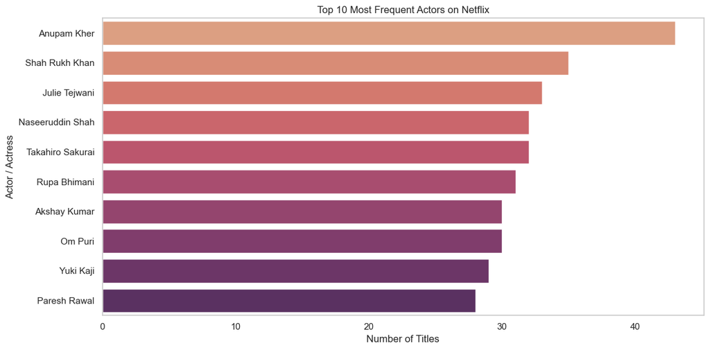

```python
plt.figure(figsize=(12,6))
sns.barplot(data=actor_df, x='count', y='actor', palette = 'flare')
plt.title("Top 10 Most Frequent Actors on Netflix")
plt.xlabel("Number of Titles")
plt.ylabel("Actor / Actress")
plt.grid(axis='x')
plt.tight_layout()
plt.show()
```

```python
!pip install wordcloud
```

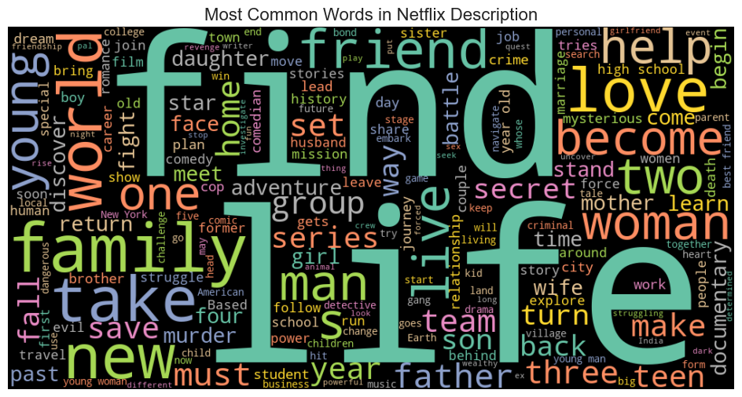

```python
from wordcloud import WordCloud, STOPWORDS

text=" ".join(df['description'].dropna())

stopwords = set(STOPWORDS)

wordcloud = WordCloud(width = 1000, height = 500, background_color='black', stopwords = stopwords, colormap='Set2', random_state=42).generate(text)

plt.figure(figsize=(12,6))
plt.imshow(wordcloud, interpolation ='bilinear')
plt.axis('off')
plt.title("Most Common Words in Netflix Description", fontsize=16)
plt.show()
```

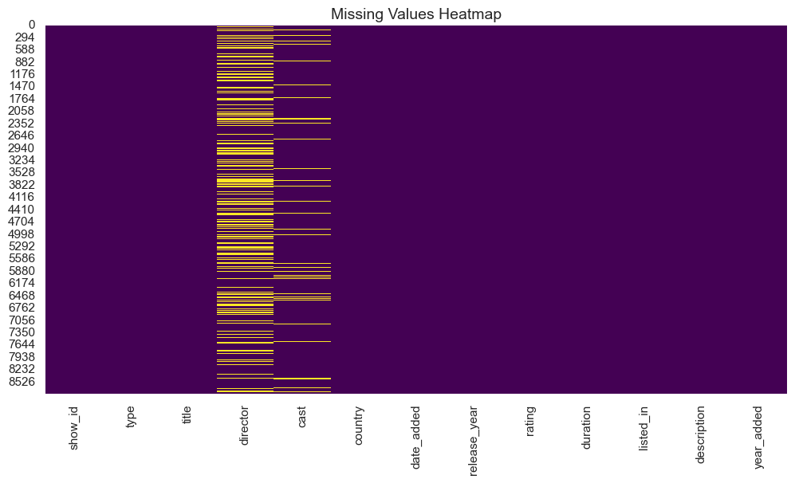

```python
plt.figure(figsize=(12,6))
sns.heatmap(df.isnull(), cbar=False, cmap='viridis')
plt.title("Missing Values Heatmap", fontsize=14)
plt.show()
```

Correlation Matrix -

Examined correlations between release_year, year_added, and duration_int

Found a mild positive correlation between release year and added year

Newer content tends to have shorter runtimes

```python
df['date_added'] = pd.to_datetime(df['date_added'])


df['year_added'] = df['date_added'].dt.year


df['duration_int'] = df['duration'].str.extract('(\d+)').astype(float)


num_df = df[['duration_int', 'release_year', 'year_added']].copy()

corr =num_df.corr()
print(corr)
```

```
              duration_int  release_year  year_added
duration_int      1.000000     -0.249182    0.029345
release_year     -0.249182      1.000000    0.111531
year_added        0.029345      0.111531    1.000000
```

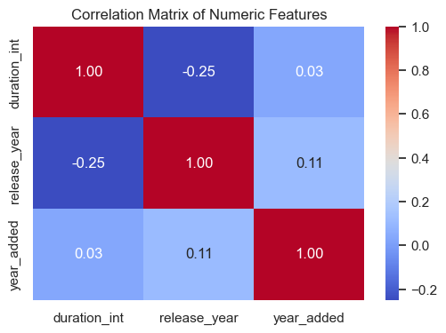

```python
plt.figure(figsize = (6,4))
sns.heatmap(corr, annot=True, cmap='coolwarm', fmt=".2f")
plt.title("Correlation Matrix of Numeric Features")
plt.show()
```

```python
genre_rating_df = df[['listed_in','rating']].dropna().copy()

genre_rating_df['listed_in'] = genre_rating_df['listed_in'].apply(lambda x: x.split(', '))
genre_rating_df = genre_rating_df.explode('listed_in')

genre_rating_counts = genre_rating_df.groupby(['listed_in', 'rating']).size().reset_index(name='count')

genre_rating_counts = genre_rating_counts.sort_values(by='count', ascending=False)
```

```
<function matplotlib.pyplot.show(close=None, block=None)>
```

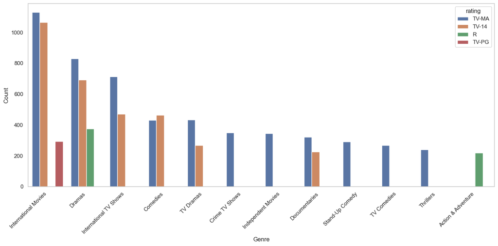

```python
plt.figure(figsize=(14,7))
sns.barplot(data=genre_rating_counts.head(20), x='listed_in', y='count', hue='rating')
plt.xticks(rotation = 45, ha='right')
plt.xlabel("Genre")
plt.ylabel("Count")
plt.tight_layout()
plt.grid(axis='y')
plt.show
```

```python
df['date_added'] = pd.to_datetime(df['date_added'])
df['year_added'] = df['date_added'].dt.year
df['month_added'] = df['date_added'].dt.month_name()

#grouping by year and month and count content added

monthly_trends = df.groupby(['year_added','month_added']).size().reset_index(name='count')

#To plot months in calendar order, define category with month names ordered

months_order = ["January", "February", "March", "April", "May", "June", "July", "August", "September", "October", "November", "December"]

monthly_trends['month_added'] = pd.Categorical(monthly_trends['month_added'], categories = months_order, ordered = True)

monthly_trends = monthly_trends.sort_values(by=['year_added','month_added'])
```

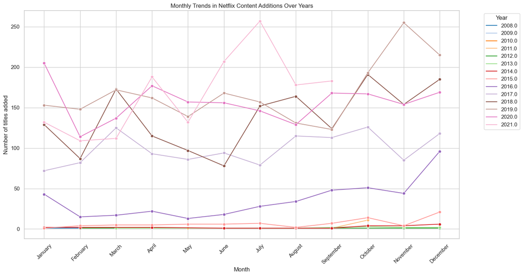

```python
plt.figure(figsize=(15,8))
sns.lineplot(data=monthly_trends, x='month_added', y='count', hue='year_added', palette= 'tab20', marker = '')

plt.title("Monthly Trends in Netflix Content Additions Over Years")
plt.xlabel("Month")
plt.ylabel('Number of titles added')
plt.xticks(rotation=45)
plt.legend(title='Year', bbox_to_anchor=(1.05,1), loc='upper left')
plt.grid(True)
plt.tight_layout()
plt.show()
```

Key Takeaways -

Netflix significantly ramped up its content between 2017–2019

Movies dominate over TV shows

US and India are key content contributors

Genre diversity is high, with some surprises like "Independent Movies"

Ratings like TV-MA dominate, hinting at mature content focus